# Identifying Potential Clients

### Identifying Potential Clients Using C5.0 Decision Trees

The increasing number of marketing campaigns over time has reduced their effects on the general public. First, due to competition, positive response rate to mass campaigns are typically very low, according to a recent study, less than 1% of the contacts will subscribe a term deposit. Second, direct marketing has drawbacks, such as causing negative attitude towards banks due to intrusion of privacy and frequent promotional contacts. In order to save costs and time and improve customer satisfaction, it is important to filter the contacts but keep a certain success rate. Machine learning has been applied widely to help enterprises to identify potential clients, targets. Nowadays, target marketing is becoming popular, and machine learning is playing a crucial role in its success. In a wide variety of algorithms, Decision tree is widely used in the banking industry or the marketing feild due to their high accuracy and ability to formulate a statistical model in plain language. My goal of analysis is to develop a classifier using C5.0 decision trees to predict whether or not a client will subscribe a term deposit with high accuracy but also with high sensitivity.

## Step 1 - Collecting data —-

I will utilize the Bank Marketing Dataset bank-full.csv from the UCI Machine Learning Repository at http://archive.ics.uci.edu/ml. The data is related with direct marketing campaigns (phone calls) of a Portuguese banking institution. It includes 45,211 examples, 17 variables: a class variable indicating whether a client subscribes a term deposit and 16 features. The 17 variables are discribed as following:

# Demographic and financial information:

1 - age (numeric) 2 - job : type of job (categorical:‘admin.’,‘blue-collar’,‘entrepreneur’,‘housemaid’,‘management’,‘retired’,‘self-employed’,‘services’,‘student’,‘technician’,‘unemployed’,‘unknown’) 3 - marital : marital status (categorical: ‘divorced’,‘married’,‘single’,‘unknown’; note: ‘divorced’ means divorced or widowed) 4 - education (categorical:‘basic.4y’,‘basic.6y’,‘basic.9y’,‘high.school’,‘illiterate’,‘professional.course’,‘university.degree’,‘unknown’) 5 - default: has credit in default? (categorical: ‘no’,‘yes’,‘unknown’) 6 - balance (numeric) 7 - housing: has housing loan? (categorical: ‘no’,‘yes’,‘unknown’) 8 - loan: has personal loan? (categorical: ‘no’,‘yes’,‘unknown’)

# Related with the last contact of the current campaign:

9 - contact: contact communication type (categorical: ‘cellular’,‘telephone’) 10 - month: last contact month of year (categorical: ‘jan’, ‘feb’, ‘mar’, …, ‘nov’, ‘dec’) 11 - day: last contact day of the month (categorical) 12 - duration: last contact duration, in seconds (numeric). # Contact history: 13 - campaign: number of contacts performed during this campaign and for this client (numeric, includes last contact) 14 - pdays: number of days that passed by after the client was last contacted from a previous campaign (numeric; 999 means client was not previously contacted) 15 - previous: number of contacts performed before this campaign and for this client (numeric) 16 - poutcome: outcome of the previous marketing campaign (categorical: ‘failure’, ‘nonexistent’, ‘success’)

# Output variable (desired target):

17 - y : has the client subscribed a term deposit? (binary: ‘yes’,‘no’)

## Step 2: Exploring and preparing the data —-

Explore the data to see whether we can use the data to classify and prepare the data for modeling.

# Import data

Import the data into R

```r
#Import the CSV file.
bank <- read.table("bank-full.csv", sep=";", header=T)
str(bank)
```

```
## 'data.frame':    45211 obs. of  17 variables:
##  $ age      : int  58 44 33 47 33 35 28 42 58 43 ...
##  $ job      : Factor w/ 12 levels "admin.","blue-collar",..: 5 10 3 2 12 5 5 3 6 10 ...
##  $ marital  : Factor w/ 3 levels "divorced","married",..: 2 3 2 2 3 2 3 1 2 3 ...
##  $ education: Factor w/ 4 levels "primary","secondary",..: 3 2 2 4 4 3 3 3 1 2 ...
##  $ default  : Factor w/ 2 levels "no","yes": 1 1 1 1 1 1 1 2 1 1 ...
##  $ balance  : int  2143 29 2 1506 1 231 447 2 121 593 ...
##  $ housing  : Factor w/ 2 levels "no","yes": 2 2 2 2 1 2 2 2 2 2 ...
##  $ loan     : Factor w/ 2 levels "no","yes": 1 1 2 1 1 1 2 1 1 1 ...
##  $ contact  : Factor w/ 3 levels "cellular","telephone",..: 3 3 3 3 3 3 3 3 3 3 ...
##  $ day      : int  5 5 5 5 5 5 5 5 5 5 ...
##  $ month    : Factor w/ 12 levels "apr","aug","dec",..: 9 9 9 9 9 9 9 9 9 9 ...
##  $ duration : int  261 151 76 92 198 139 217 380 50 55 ...
##  $ campaign : int  1 1 1 1 1 1 1 1 1 1 ...
##  $ pdays    : int  -1 -1 -1 -1 -1 -1 -1 -1 -1 -1 ...
##  $ previous : int  0 0 0 0 0 0 0 0 0 0 ...
##  $ poutcome : Factor w/ 4 levels "failure","other",..: 4 4 4 4 4 4 4 4 4 4 ...
##  $ y        : Factor w/ 2 levels "no","yes": 1 1 1 1 1 1 1 1 1 1 ...
```

# Data undersanding and cleaning

```r
summary(bank)
```

```
##       age                 job           marital          education
##  Min.   :18.00   blue-collar:9732   divorced: 5207   primary  : 6851
##  1st Qu.:33.00   management :9458   married :27214   secondary:23202
##  Median :39.00   technician :7597   single  :12790   tertiary :13301
##  Mean   :40.94   admin.     :5171                    unknown  : 1857
##  3rd Qu.:48.00   services   :4154
##  Max.   :95.00   retired    :2264
##                  (Other)    :6835
##  default        balance       housing      loan            contact
##  no :44396   Min.   : -8019   no :20081   no :37967   cellular :29285
##  yes:  815   1st Qu.:    72   yes:25130   yes: 7244   telephone: 2906
##              Median :   448                           unknown  :13020
##              Mean   :  1362
##              3rd Qu.:  1428
##              Max.   :102127
##
##       day            month          duration         campaign
##  Min.   : 1.00   may    :13766   Min.   :   0.0   Min.   : 1.000
##  1st Qu.: 8.00   jul    : 6895   1st Qu.: 103.0   1st Qu.: 1.000
##  Median :16.00   aug    : 6247   Median : 180.0   Median : 2.000
##  Mean   :15.81   jun    : 5341   Mean   : 258.2   Mean   : 2.764
##  3rd Qu.:21.00   nov    : 3970   3rd Qu.: 319.0   3rd Qu.: 3.000
##  Max.   :31.00   apr    : 2932   Max.   :4918.0   Max.   :63.000
##                  (Other): 6060
##      pdays          previous           poutcome       y
##  Min.   : -1.0   Min.   :  0.0000   failure: 4901   no :39922
##  1st Qu.: -1.0   1st Qu.:  0.0000   other  : 1840   yes: 5289
##  Median : -1.0   Median :  0.0000   success: 1511
##  Mean   : 40.2   Mean   :  0.5803   unknown:36959
##  3rd Qu.: -1.0   3rd Qu.:  0.0000
##  Max.   :871.0   Max.   :275.0000
##
```

```r
# convert day from numeric  to factor
bank$day=factor(bank$day)
```

# Data exploration

Let’s take a look at outputs for a couple of features that seem likely to predict if a client is going to subscribes a term deposit. From the results, features of education, job, durtion are likely to help to identify potential clients, but age and campaign seem not. The higher the education level is, the more likely a client will subscribe. The students are most likely to response with 28.7% response rate, and retired people, 22.8%,and bule-collars are the least likely to response with 7.3% response rate. The term deposit subscribers talked much longer, with average 537 seconds, than nonsubscriber with 221 seconds in the last contact. The distributions of age and campaign by target variable y seem same.

```r
# look at characteristics of the clients
prop.table(table(bank$education, bank$y),1)
```

```
##
##                     no        yes
##   primary   0.91373522 0.08626478
##   secondary 0.89440565 0.10559435
##   tertiary  0.84993610 0.15006390
##   unknown   0.86429725 0.13570275
```

```r
prop.table(table(bank$job , bank$y),1)
```

```
##
##                         no        yes
##   admin.        0.87797331 0.12202669
##   blue-collar   0.92725031 0.07274969
##   entrepreneur  0.91728312 0.08271688
##   housemaid     0.91209677 0.08790323
##   management    0.86244449 0.13755551
##   retired       0.77208481 0.22791519
##   self-employed 0.88157061 0.11842939
##   services      0.91116996 0.08883004
##   student       0.71321962 0.28678038
##   technician    0.88943004 0.11056996
##   unemployed    0.84497314 0.15502686
##   unknown       0.88194444 0.11805556
```

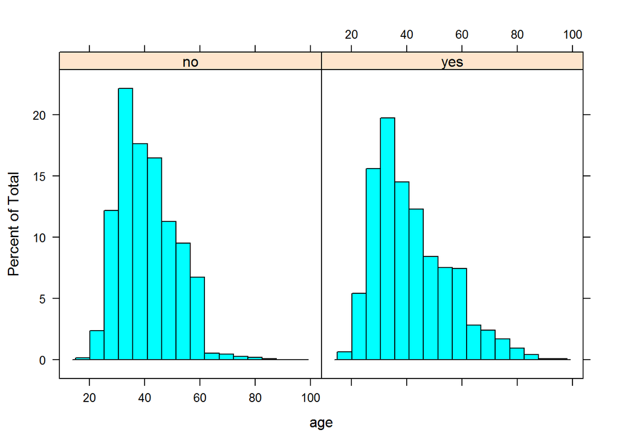

```r
library('lattice')
histogram(~ age | y, data = bank)
```

```r
# look at two characteristics of the contact
tapply(bank$duration,bank$y,summary)
```

```
## $no
##    Min. 1st Qu.  Median    Mean 3rd Qu.    Max.
##     0.0    95.0   164.0   221.2   279.0  4918.0
##
## $yes
##    Min. 1st Qu.  Median    Mean 3rd Qu.    Max.
##     8.0   244.0   426.0   537.3   725.0  3881.0
```

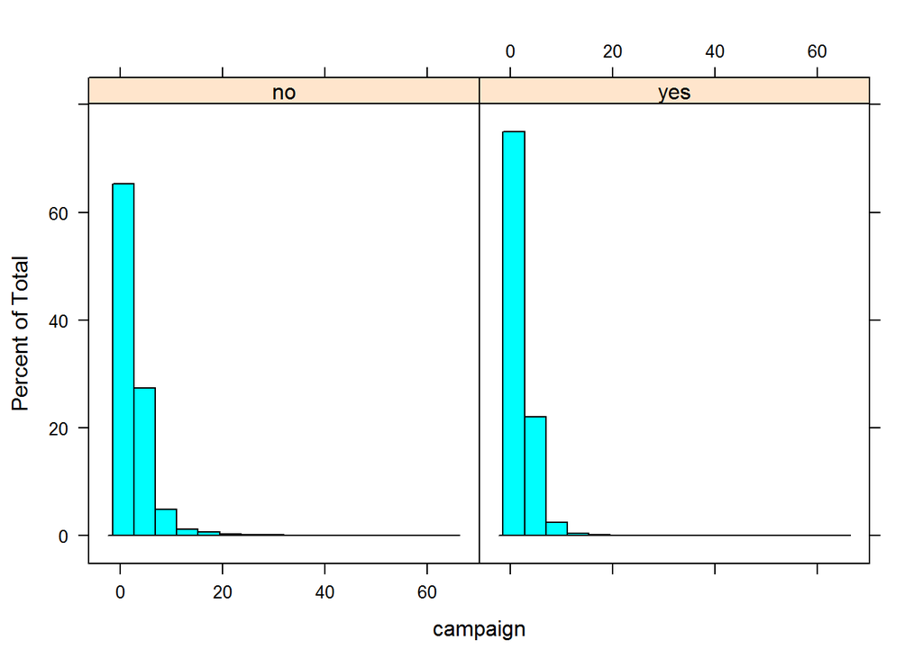

```r
histogram(~ campaign | y, data = bank)
```

look at the class variable. A total of 11.7% of the clients in this dataset subscribed the term deposit. This is a very imbalanced data!

```r
# look at the class variable
table(bank$y)/45211
```

```
##
##        no       yes
## 0.8830152 0.1169848
```

# Data preparation - creating training and test datasets

Create training and test data to build models.

```r
# split the data frames to training and test data
index=sample(1:nrow(bank),as.integer(.8*nrow(bank)))
bank_train <- bank[index, ]
bank_test  <- bank[-index, ]
```

check the proportion of class variable in training and test datasets. They are close, this appears to be a fairly even split.

```r
# check the proportion of class variable
prop.table(table(bank_train$y))
```

```
##
##        no       yes
## 0.8826311 0.1173689
```

```r
prop.table(table(bank_test$y))
```

```
##
##        no       yes
## 0.8845516 0.1154484
```

## Step 3: Training a model on the data —-

This time, we train a simplest decision tree model on the data.

```r
# build the simplest decision tree

library(C50)
bank_model <- C5.0(bank_train[-17], bank_train$y)
```

```r
# display simple facts about the tree
bank_model
```

```
##
## Call:
## C5.0.default(x = bank_train[-17], y = bank_train$y)
##
## Classification Tree
## Number of samples: 36168
## Number of predictors: 16
##
## Tree size: 474
##
## Non-standard options: attempt to group attributes
```

```r
# display detailed information about the tree
summary(bank_model)
```

```
##
## Call:
## C5.0.default(x = bank_train[-17], y = bank_train$y)
##
##
## C5.0 [Release 2.07 GPL Edition]      Sun Nov 26 15:33:15 2017
## -------------------------------
##
## Class specified by attribute `outcome'
##
## Read 36168 cases (17 attributes) from undefined.data
##
## Decision tree:
##
## poutcome = success:
## :...duration <= 162:
## :   :...duration <= 80: no (56/3)
## :   :   duration > 80:
## :   :   :...job in {admin.,blue-collar,entrepreneur,student,
## :   :       :       technician}: no (107/26)
## :   :       job = unknown: yes (1)
## :   :       job = housemaid:
## :   :       :...education in {primary,tertiary}: yes (4)
## :   :       :   education in {secondary,unknown}: no (5)
## :   :       job = retired:
## :   :       :...housing = no: no (19/5)
## :   :       :   housing = yes: yes (2)
## :   :       job = services:
## :   :       :...marital in {divorced,married}: yes (5/1)
## :   :       :   marital = single: no (2)
## :   :       job = unemployed:
## :   :       :...previous <= 2: no (3)
## :   :       :   previous > 2: yes (3/1)
## :   :       job = management:
## :   :       :...month in {apr,dec,jan,jun,mar,may,oct,sep}: no (38/17)
## :   :       :   month in {aug,jul}:
## :   :       :   :...pdays <= 97: yes (3)
## :   :       :   :   pdays > 97: no (10/1)
## :   :       :   month in {feb,nov}:
## :   :       :   :...day in {2,5,16}: no (7/1)
```

[output cut: 866 more lines]

```
##   48.96% contact
##   36.52% day
##   29.35% pdays
##    9.70% housing
##    6.64% loan
##    3.33% default
##    2.46% job
##    1.43% marital
##    1.10% campaign
##    0.71% education
##    0.62% balance
##    0.58% previous
##
##
## Time: 0.4 secs
```

## Step 4: Evaluating model performance —-

```r
# create a factor vector of predictions on test data
bank_pred <- predict(bank_model, bank_test)
predicted_prob <- predict(bank_model, bank_test, type = "prob")

# confusion matrix
library(gmodels)
CrossTable(bank_test$y, bank_pred,
           prop.chisq = FALSE, prop.c = FALSE, prop.r = FALSE,
           dnn = c('actual subscriber', 'predicted subscriber'))
```

```
##
##
##    Cell Contents
## |-------------------------|
## |                       N |
## |         N / Table Total |
## |-------------------------|
##
##
## Total Observations in Table:  9043
##
##
##                   | predicted subscriber
## actual subscriber |        no |       yes | Row Total |
## ------------------|-----------|-----------|-----------|
##                no |      7694 |       305 |      7999 |
##                   |     0.851 |     0.034 |           |
## ------------------|-----------|-----------|-----------|
##               yes |       552 |       492 |      1044 |
##                   |     0.061 |     0.054 |           |
## ------------------|-----------|-----------|-----------|
##      Column Total |      8246 |       797 |      9043 |
## ------------------|-----------|-----------|-----------|
##
##
```

```r
# compute accuracy
accuracy <- mean(bank_test$y==bank_pred)
accuracy
```

```
## [1] 0.9052306
```

```r
# KAPPA
library(vcd)
Kappa(table(bank_test$y, bank_pred))
```

```
##             value     ASE     z   Pr(>|z|)
## Unweighted 0.4828 0.01509 31.99 1.525e-224
## Weighted   0.4828 0.01509 31.99 1.525e-224
```

```r
# sensitivity
sens <- sum(bank_test$y=="yes" & bank_pred=="yes")/sum(bank_test$y=="yes")
sens
```

```
## [1] 0.4712644
```

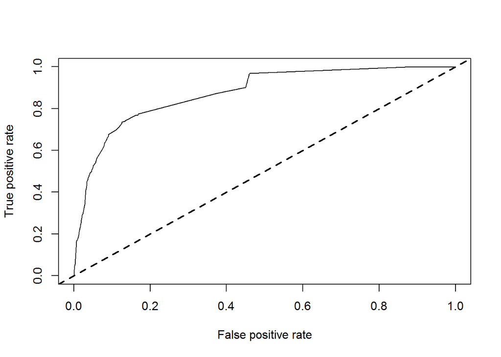

```r
# ROC Curve

library(ROCR)
library(gplots)
pred <- prediction( predicted_prob[,2], bank_test$y)
perf <- performance(pred, measure = "tpr", x.measure = "fpr")
plot(perf)
abline(a = 0, b = 1, lwd = 2, lty = 2)
```

```r
perf.auc <- performance(pred, measure = "auc")
unlist(perf.auc@y.values)
```

```
## [1] 0.8757881
```

## Step 5: Improving model performance —-

I will attempt two ways to improve model performance. First, I will employ boosting. This is a process in which many decision trees are built and the trees vote on the best class for each example. Second, we will assign a penalty to different types of errors, in order to discourage a tree from making more costly mistakes. The penalties are designated in a cost matrix, which specifies how much costlier each error is, relative to any other prediction.

# Boosting the accuracy of decision trees

```r
# boosted decision tree with 10 trials
bank_boost10 <- C5.0(bank_train[-17], bank_train$y,
                       trials = 10)
bank_boost10
```

```
##
## Call:
## C5.0.default(x = bank_train[-17], y = bank_train$y, trials = 10)
##
## Classification Tree
## Number of samples: 36168
## Number of predictors: 16
##
## Number of boosting iterations: 10
## Average tree size: 456.3
##
## Non-standard options: attempt to group attributes
```

```r
summary(bank_boost10)
```

```
##
## Call:
## C5.0.default(x = bank_train[-17], y = bank_train$y, trials = 10)
##
##
## C5.0 [Release 2.07 GPL Edition]      Sun Nov 26 15:33:19 2017
## -------------------------------
##
## Class specified by attribute `outcome'
##
## Read 36168 cases (17 attributes) from undefined.data
##
## -----  Trial 0:  -----
##
## Decision tree:
##
## poutcome = success:
## :...duration <= 162:
## :   :...duration <= 80: no (56/3)
## :   :   duration > 80:
## :   :   :...job in {admin.,blue-collar,entrepreneur,student,
## :   :       :       technician}: no (107/26)
## :   :       job = unknown: yes (1)
## :   :       job = housemaid:
## :   :       :...education in {primary,tertiary}: yes (4)
## :   :       :   education in {secondary,unknown}: no (5)
## :   :       job = retired:
## :   :       :...housing = no: no (19/5)
## :   :       :   housing = yes: yes (2)
## :   :       job = services:
## :   :       :...marital in {divorced,married}: yes (5/1)
## :   :       :   marital = single: no (2)
## :   :       job = unemployed:
## :   :       :...previous <= 2: no (3)
## :   :       :   previous > 2: yes (3/1)
## :   :       job = management:
## :   :       :...month in {apr,dec,jan,jun,mar,may,oct,sep}: no (38/17)
## :   :       :   month in {aug,jul}:
## :   :       :   :...pdays <= 97: yes (3)
## :   :       :   :   pdays > 97: no (10/1)
```

[output cut: 11124 more lines]

```
##   99.98% day
##   99.76% contact
##   99.18% job
##   93.53% balance
##   91.19% loan
##   81.84% pdays
##   79.25% default
##   77.06% campaign
##   75.68% education
##   73.97% previous
##   56.28% housing
##   50.74% marital
##
##
## Time: 4.0 secs
```

Evaluate the performance

```r
bank_boost_pred10 <- predict(bank_boost10, bank_test)
CrossTable(bank_test$y, bank_boost_pred10,
           prop.chisq = FALSE, prop.c = FALSE, prop.r = FALSE,
           dnn = c('actual', 'predicted'))
```

```
##
##
##    Cell Contents
## |-------------------------|
## |                       N |
## |         N / Table Total |
## |-------------------------|
##
##
## Total Observations in Table:  9043
##
##
##              | predicted
##       actual |        no |       yes | Row Total |
## -------------|-----------|-----------|-----------|
##           no |      7687 |       312 |      7999 |
##              |     0.850 |     0.035 |           |
## -------------|-----------|-----------|-----------|
##          yes |       571 |       473 |      1044 |
##              |     0.063 |     0.052 |           |
## -------------|-----------|-----------|-----------|
## Column Total |      8258 |       785 |      9043 |
## -------------|-----------|-----------|-----------|
##
##
```

```r
# compute accuracy
accuracy=mean(bank_test$y==bank_boost_pred10)
accuracy
```

```
## [1] 0.9023554
```

```r
# KPPA
Kappa(table(bank_test$y, bank_boost_pred10))
```

```
##             value     ASE     z   Pr(>|z|)
## Unweighted 0.4641 0.01523 30.47 5.912e-204
## Weighted   0.4641 0.01523 30.47 5.912e-204
```

```r
# sensitivity
sens <- sum(bank_test$y=="yes" & bank_boost_pred10=="yes")/sum(bank_test$y=="yes")
sens
```

```
## [1] 0.4530651
```

# assign a penalty to different types of errors

Failing to identify a client of a term deposit can be an expensive mistake. Fortunately,the C5.0 algorithm allows us to assign a penalty to different types of errors.

Training the model

```r
# create dimensions for a cost matrix
matrix_dimensions <- list(c("no", "yes"), c("no", "yes"))
names(matrix_dimensions) <- c("predicted", "actual")
matrix_dimensions
```

```
## $predicted
## [1] "no"  "yes"
##
## $actual
## [1] "no"  "yes"
```

```r
# build the matrix
error_cost <- matrix(c(0, 1, 4, 0), nrow = 2, dimnames = matrix_dimensions)
error_cost
```

```
##          actual
## predicted no yes
##       no   0   4
##       yes  1   0
```

```r
# apply the cost matrix to the tree
bank_cost <- C5.0(bank_train[-17], bank_train$y,
                    costs = error_cost)

# display simple facts about the tree
bank_cost
```

```
##
## Call:
## C5.0.default(x = bank_train[-17], y = bank_train$y, costs = error_cost)
##
## Classification Tree
## Number of samples: 36168
## Number of predictors: 16
##
## Tree size: 465
##
## Non-standard options: attempt to group attributes
##
## Cost Matrix:
##          actual
## predicted no yes
##       no   0   4
##       yes  1   0
```

```r
# display detailed information about the tree
summary(bank_cost)
```

```
##
## Call:
## C5.0.default(x = bank_train[-17], y = bank_train$y, costs = error_cost)
##
##
## C5.0 [Release 2.07 GPL Edition]      Sun Nov 26 15:33:26 2017
## -------------------------------
##
## Class specified by attribute `outcome'
##
## Read 36168 cases (17 attributes) from undefined.data
## Read misclassification costs from undefined.costs
##
## Decision tree:
##
## poutcome = success:
## :...duration > 132: yes (1029/275)
## :   duration <= 132:
## :   :...duration <= 62: no (25)
## :       duration > 62:
## :       :...contact = telephone: no (9)
## :           contact = unknown: yes (1)
## :           contact = cellular:
## :           :...month in {apr,aug,feb,jun,mar,nov,oct,sep}: yes (128/89)
## :               month in {dec,jan,jul,may}:
## :               :...balance <= 5078: no (30)
## :                   balance > 5078: yes (2/1)
## poutcome in {failure,other,unknown}:
## :...duration > 365:
##     :...duration > 633:
##     :   :...duration > 827: yes (1370/592)
##     :   :   duration <= 827:
##     :   :   :...contact = unknown:
##     :   :       :...marital in {divorced,single}: yes (148/91)
##     :   :       :   marital = married:
##     :   :       :   :...default = yes: yes (3/1)
##     :   :       :       default = no:
##     :   :       :       :...day in {1,2,6,10,11,16,22,25,26,27,28,
##     :   :       :           :       31}: yes (55/35)
##     :   :       :           day in {4,7,8,12,24}: no (23)
```

[output cut: 1057 more lines]

```
##   86.30% day
##   70.08% job
##   55.80% contact
##   28.16% pdays
##   20.57% previous
##   18.10% campaign
##   15.45% housing
##   11.65% balance
##    6.02% marital
##    5.30% loan
##    4.45% default
##    2.30% education
##
##
## Time: 0.6 secs
```

```r
#Generate predictions on the test data
bank_cost_pred <- predict(bank_cost, bank_test)
```

Evaluation of the cost model

```r
# evaluatation the cost model
# confussion matrix
CrossTable(bank_test$y, bank_cost_pred,
           prop.chisq = FALSE, prop.c = FALSE, prop.r = FALSE,
           dnn = c('actual', 'predicted'))
```

```
##
##
##    Cell Contents
## |-------------------------|
## |                       N |
## |         N / Table Total |
## |-------------------------|
##
##
## Total Observations in Table:  9043
##
##
##              | predicted
##       actual |        no |       yes | Row Total |
## -------------|-----------|-----------|-----------|
##           no |      7071 |       928 |      7999 |
##              |     0.782 |     0.103 |           |
## -------------|-----------|-----------|-----------|
##          yes |       209 |       835 |      1044 |
##              |     0.023 |     0.092 |           |
## -------------|-----------|-----------|-----------|
## Column Total |      7280 |      1763 |      9043 |
## -------------|-----------|-----------|-----------|
##
##
```

```r
# compute accuracy
accuracy=mean(bank_test$y==bank_cost_pred)
accuracy
```

```
## [1] 0.8742674
```

```r
# KPPA
Kappa(table(bank_test$y, bank_cost_pred))
```

```
##             value     ASE     z Pr(>|z|)
## Unweighted 0.5262 0.01203 43.76        0
## Weighted   0.5262 0.01203 43.76        0
```

```r
# sensitivity
sens <- sum(bank_test$y=="yes" & bank_cost_pred=="yes")/sum(bank_test$y=="yes")
sens
```

```
## [1] 0.7998084
```

Combine predictions made from the test data using this final model, C5.0 with cost function, into the bank test data and present the predictions. From the result, the classes of the first 6 examples in the test data are all nos, and the predictions for those are also all nos. The model predicts them correctly.

```r
bank_test$prediction=bank_cost_pred

head(bank_test)
```

```
##    age          job  marital education default balance housing loan
## 1   58   management  married  tertiary      no    2143     yes   no
## 2   44   technician   single secondary      no      29     yes   no
## 8   42 entrepreneur divorced  tertiary     yes       2     yes   no
## 18  57  blue-collar  married   primary      no      52     yes   no
## 24  25     services  married secondary      no      50     yes   no
## 35  51   management  married  tertiary      no   10635     yes   no
##    contact day month duration campaign pdays previous poutcome  y
## 1  unknown   5   may      261        1    -1        0  unknown no
## 2  unknown   5   may      151        1    -1        0  unknown no
## 8  unknown   5   may      380        1    -1        0  unknown no
## 18 unknown   5   may       38        1    -1        0  unknown no
## 24 unknown   5   may      342        1    -1        0  unknown no
## 35 unknown   5   may      336        1    -1        0  unknown no
##    prediction
## 1          no
## 2          no
## 8          no
## 18         no
## 24         no
## 35         no
```